# Working with Random Variables in R

### Applications

**Many!!** Because of a theorem called the **Central Limit Theorem** many distributions are at least approximately normal. These distributions are also important for doing statistics.

Examples: IQ scores; SAT scores; heights of adult men in a community; etc.

**Example 3.**  
The height of North American adult males has (approximately) a normal distribution with mean = 70 inches and sd = 3 inches.

1. What proportion of North American adult males are 6 ft = 72 inches or less?
2. What is the 99th percentile for height?

```r
# P(X <= 72)
pnorm(72, mean = 70, sd = 3)
```

```
## [1] 0.7475075
```

```r
# 99th percentile
qnorm(0.99, mean = 70, sd = 3)
```

```
## [1] 76.97904
```

### 68-95-99.7 Rule

For all normal distributions

- $\operatorname{P}( \mu -\sigma \le X \le \mu + \sigma) \approx$ 68%

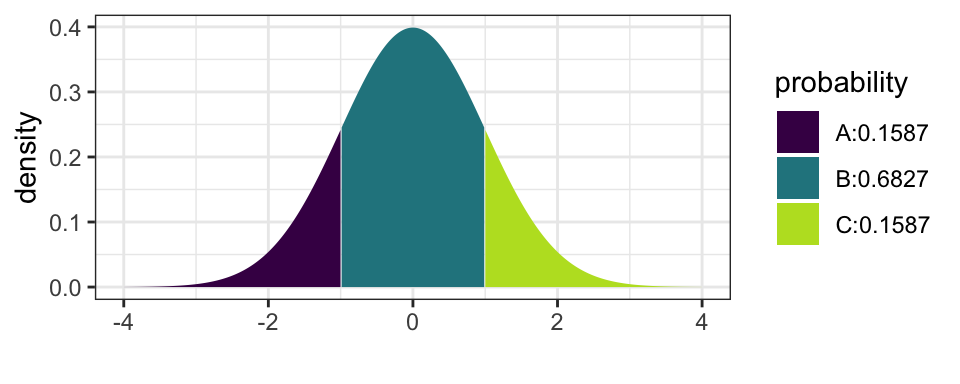

- $\operatorname{P}( \mu -2\sigma \le X \le \mu + 2\sigma) \approx$ 95%

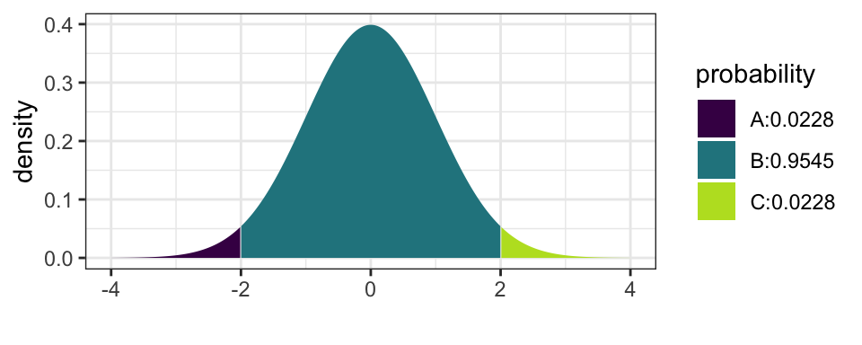

- $\operatorname{P}( \mu -3\sigma \le X \le \mu + 3\sigma) \approx$ 99.7%

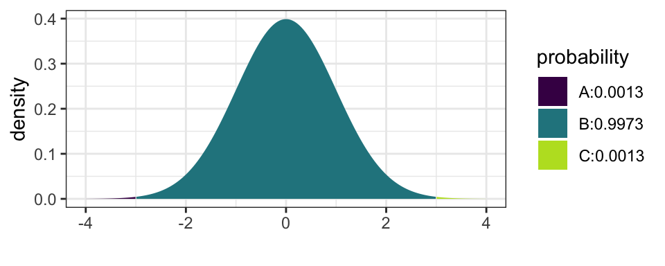

## Binomial Distribution (`binom`)

**parameters:** `size` ($n$) and `prob` ($p$)

**plots** for discrete distributions look a little different.

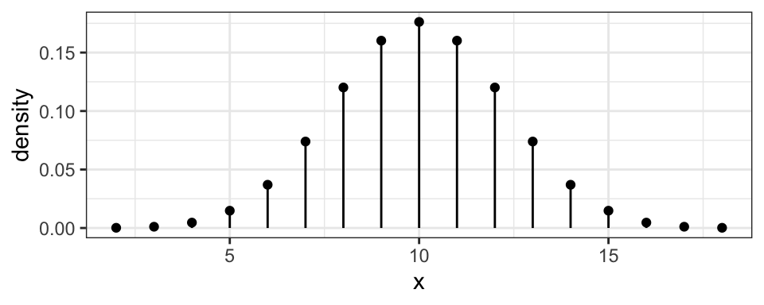

```r
gf_dist('binom', size = 20, prob = 0.5)
```

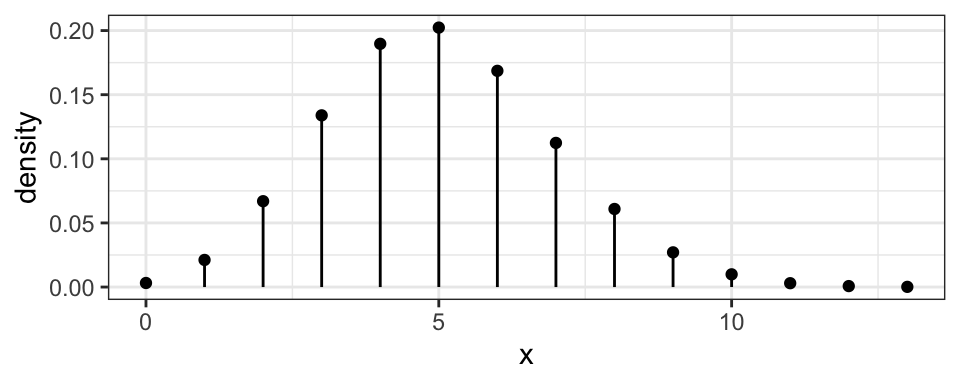

```r
gf_dist('binom', size = 20, prob = 0.25)
```

But otherwise things work basically the same. The pmf is `dbinom()`, and we have `pbinom()`, `qbinom()` and `rbinom()` just like for the otehr distributions we have seen.

**Example 4.** Compute the mean of a ${\sf Binom}(20, 0.25)$ distribution in R.

Notice that we use `sum()` not `integrate()` because this is a discrete distribution.

```r
values <- 0:20
probs <- dbinom(values, 20, 0.25)
sum(values * probs)
```

```
## [1] 5
```

That’s a reasonable answer: If our probability of success is 25% and we try 20 times, we should average 5 success.

## More distributions

There are many more families of distributions.

- Our text discusses a number of distributions, and we will see more distributions in examples as we go along.
- Wikipedia is actually a good place to look up information about a particular family. Here is a [list of distributions](https://en.wikipedia.org/wiki/List_of_probability_distributions) that Wikipedia has pages about.
- The **Univariate Distribution Relationships** site shows relationships among and provides important information about many commonly used distributions.
  - [interactive version](http://www.math.wm.edu/~leemis/chart/UDR/UDR.html)
  - [PDF version](http://www.math.wm.edu/~leemis/2008amstat.pdf#page=3)
- Note: Some times there is more than one way to parameterize a family of distributions. Always check to see that you know the paramterization being used. (Example: some people use mean and variance instead of mean and standard deviation for the normal distributions.)

## More Practice

**1.** IQ scores are (approximately) normally distributed with mean = 100 and sd = 15. Answer the following with the 68-95-99.7 rule when you can, using R otherwise.

1. What percent of people have IQ scores in the range 85 to 115?
2. What perent of peple have IQ scores higher than 130?
3. What percent of people have IQ scores in the range 90 to 110?
4. Carol has an IQ score of 128. What percent of people have IQ scores no higher than Carol’s IQ score?
5. Born in 1982, Christopher Hirata had recorded an IQ of 225. He is an outstanding example of child prodigy who had already completed his college level courses by the time he was 12. By the time he turned 16, he was working on a project with the NASA. He was the first one to win a gold medal in international Science Olympiad at the age of 13. He began attending classes for his PhD in astrophysics when he was just 18. At what percentile is his IQ score?
6. What is the 99th percentile for IQ scores?

**2.** Scores on an aptitude test are normally distributed. 16% of scores are below 20 and 2.5% of scores are above 110. Use the 68-95-99.7% rule to find the mean and standard deviation.

**3.** Another important family of distributions is the set of gamma distributions. There are two parameters for the gammas: shape ($\alpha$) and rate ($\lambda$). The kernel for a gamma distribution is
$$k(x) = x^{\alpha - 1} e^{-\lambda x} \mbox{ on } (0, \infty)$$
If shape = 1, then gamma is an exponential distribution.

1. Plot the graphs of the following gamma pdfs
   - shape = 2; rate = 4
   - shape = 5; rate = 10
   - shape = 10; rate = 5
   - shape = 4; rate = 2
2. Based on the plots above, how would you describe the general shape of a gamma distribution?
3. Find the 90th percentile of a ${\sf Gamma}(2, 4)$ distribution.
4. Find the mean and variance of the gamma distribution when shape = 4 and rate = 3. Use R to do the calculations. Then use the Wikipedia page to check your answers.

**4.** The Poisson distributions have one parameter, called $\lambda$ (lambda).

1. Use `? dpois` or `args(dpois)` to find out what this parameter is called in R.
2. Plot Poisson distributions with $\lambda = 2$, $\lambda = 4$, $\lambda = 10$, and $\lambda = 100$. What do you notice about the shape of the distribution as $\lambda$ gets larger and larger?
3. Calculate the mean of the following distributions ${\sf Pois}(10)$, ${\sf Pois}(20)$, ${\sf Pois}(5)$ using R. (Note: you will need to use `sum()`, not `integrate()`.) What do you notice? Check the Wikipedia page to see if this always holds.
4. Cacluate the median of a ${\sf Pois}(10)$ distribution using `ppois()`. What proportion of the distribution is less than the median? equal to the median? greater than the median?

**5.** Another important family of distributions is the family of beta distributions. There are two parameters for a beta distribution: shape1 and shape2.

1. Plot the graphs of the following beta pdf’s
   - shape1 = 2; shape2 = 2
   - shape1= 2; shape2 = .9
   - shape1 =4; shape2 = 2
   - shape1 = .9; shape2 = .85
2. Based on the plots above, what would you say about the shapes of a beta distribution?
3. Find the median of a ${\sf Beta}(2, 0.9)$ distribution.